# Week 8 - Support Vector Machines

### Dr. David Elliott

1.1. Introduction

1.2. Dataset Example

1.3. What is a Hyperplane?

1.4. Maximal Margin Classifier

# 1.1. Introduction

The term Support Vector Machines (SVM's) is sometimes used loosely to refer to three methods, each an extension of the previous method<sup>1</sup>:

- Maximal margin classifier,
- Support vector classifier,
- Support vector machine.

SVM's are a common supervised discriminative algorithm, well suited to *complex* small- to medium sized datasets<sup>2</sup>

They can be used for both **classification** and regression.

# 1.2. Dataset Example

To demonstrate SVM's I'll be using Fisher's (or Anderson's) Iris flowers dataset<sup>3</sup>.

The dataset consists of 50 samples each from three species of Iris (Iris setosa, Iris virginica and Iris versicolor).

```
Figure 1: Iris Flowers
```

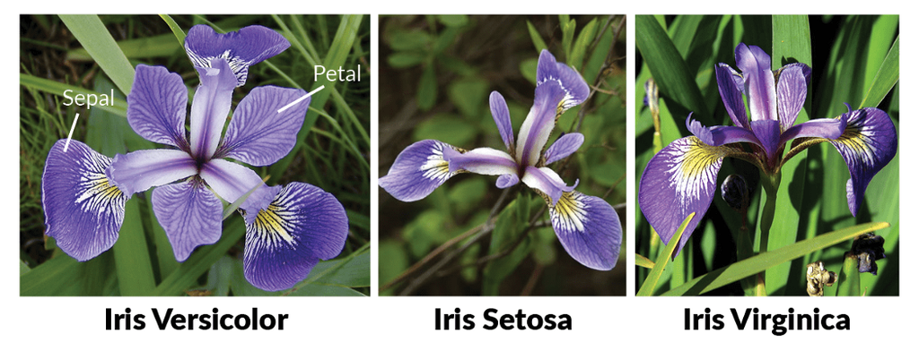

Five attributes were collected for the 150 records:

- sepal length (cm)
- sepal width (cm)
- petal length (cm)
- petal width (cm)
- species

[output not shown]

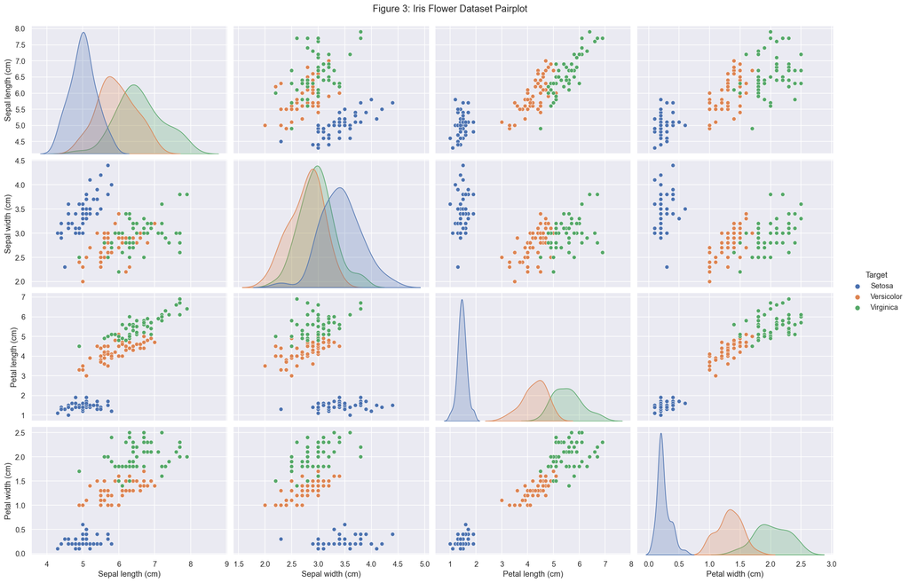

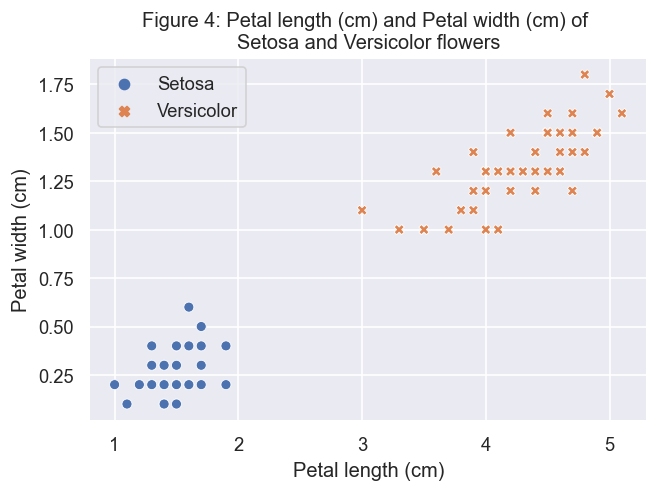

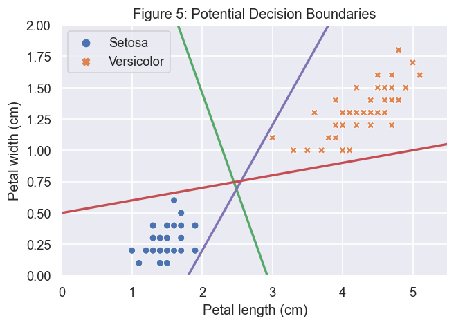

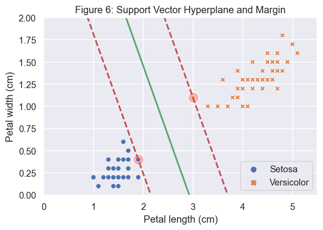

# 1.3. What is a Hyperplane?

In $p$-dimensional space, a hyperplane is a flat affine subspace of dimension $p-1$.

**Examples**

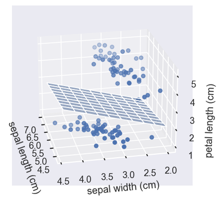

In more detail<sup>1</sup>:

*Two-dimensions*: $\beta_0 + \beta_1X_1 + \beta_2X_2 = 0$

*Three-dimensions*: $\beta_0 + \beta_1X_1 + \beta_2X_2 + \beta_3X_3 = 0$

*P-dimensions*: $\beta_0 + \beta_1X_1 + \beta_2X_2 + ... + \beta_pX_p = 0$

If $X = (X_1, ..., X_p)^T$ satisfies above, then it is a point on the hyperplane.

If $\beta_0 + \beta_1X_1 + \beta_2X_2 + ... + \beta_pX_p > 0$, it lies on one side of the hyperplane,

so if, $\beta_0 + \beta_1X_1 + \beta_2X_2 + ... + \beta_pX_p < 0$, its on the other side.

### Classifying data

We aim to classify an $n \times p$ matrix of $n$ observations in $p$ dimensional space, with these observations falling into two classes $y_1,...,y_n \in \{-1,1\}$.

If we were to perfectly separate the classes the hyperplane would have the property that

$\beta_0 + \beta_1X_{i1} + \beta_2X_{i2} + ... + \beta_pX_{ip} > 0 \quad \text{if} \ y_i = 1$,

$\beta_0 + \beta_1X_{i1} + \beta_2X_{i2} + ... + \beta_pX_{ip} < 0 \quad \text{if} \ y_i = -1$.

For a new test observations $x^*$, we would look at the sign of:

$$f(x^*) = \beta_0 + \beta_1x_1^* + \beta_2x_2^* + ... + \beta_px_p^*.$$

We would assign it to class 1 if $f(x^*)$ is positive and class -1 if negative.

Furthermore, we could use the magnitude of $f(x^*)$ to indicate how far the point lies from the hyperplane.

# 1.4. Maximal Margin Classifier

We need a reasonable way of constucting a hyperplane, out of the possible choices.

Maximal margin hyperplanes look at getting the hyperplane that is the furthest from the training observations - we compute the perpendicular distance from each training observation to a given separating hyperplane.

The maximal margin hyperplane is the separating hyperplane for which the margin is largest.

We hope the classifier with a large margin on the training data will generalise well to unseen test observations.

Another way of defining our hyperplane is:

$$w^Tx + b = 0.$$

Our margins, where our labels $y \in \{-1,1\}$, are then

$$w^Tx + b \geq 0 \text{ for } y_i +1$$$$w^Tx + b < 0 \text{ for } y_i -1$$

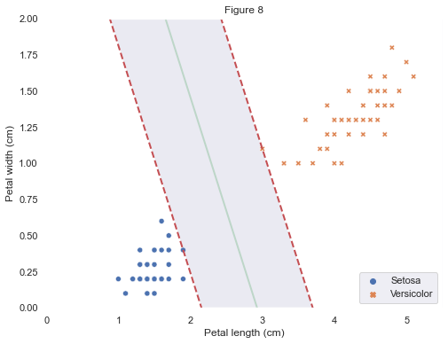

We can see below there are two equidistant points from the maximal margin hyperplane, lying on the dashed lines. These observations are called *Support Vectors*.

We can call these two points, $x_1$ and $x_2$ as below:

$$w^Tx_1 + b = 1,$$$$w^Tx_2 + b = -1.$$

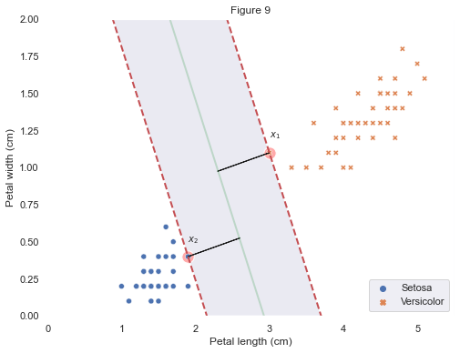

If we move our support vectors our hyperplane will too.

This is because the maximal margin hyperplane only depends on these support vectors.

Other data points could be moved without the hyperplane moving.

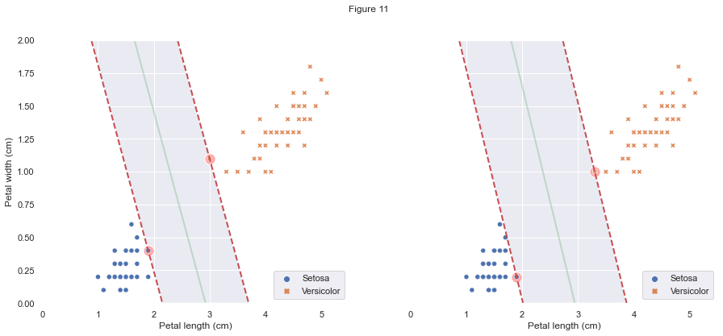

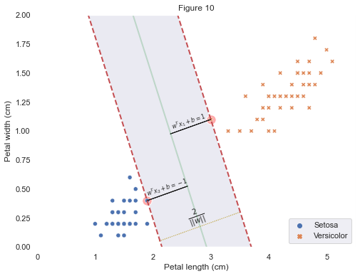

We want to maximise the distance between the margin lines, on which the points lie<sup>4</sup>.

$$x_1-x_2$$

$$ \frac{\phantom{\quad}w^Tx_1 + b = 1\\ - w^Tx_2 + b = -1 \\}{\\ w^T(x_1 - x_2) = 2} $$

$$ \frac{w^T}{||w||}(x_1 - x_2) = \frac{2}{||w||} $$

$\text{max}\frac{2}{||w||}$, while classifying everything correctly, $y_i(w^Tx_i+b) \geq 1 \quad \forall_i$.

As our two margin lines are parallel and no training points fall between them, we can find the pair of hyperplanes which gives the maximum margin by minimizing $||w||^2$. So now we have<sup>5</sup>:

${\text{min} \atop w, b}\frac{1}{2}||w||^2 \quad \text{s.t.} \quad y_i(w^Tx_i+b) \geq 1 \quad \forall_i$,

which is easier because this is a *quadratic programming problem*.

We will quickly switch to a *Lagrangian* formulation of the problem so we introduce Lagrange multipliers, $\alpha_i, i = 1, \ldots , l$, which are positive $\alpha_i \geq 1$:

$L_P \equiv \frac{1}{2}||w||^2 - \sum^l_{i=1} \alpha_iy_i(w^Tx_i+b) + \sum^l_{i=1} \alpha_i$.

We could minimise the above or maximise the following *Wolfe dual*<sup>7</sup> problem:

$L_D = \sum_i\alpha_i - \frac{1}{2}\sum_{i,j}\alpha_i\alpha_jy_iy_jx_i\cdot x_j \quad \text{s.t.} \quad \sum_i\alpha_iy_i = 0$.

This has a solution:

$w = \sum^{N_S}_{i=1}\alpha_iy_ix_i$,

where $N_S$ is the number of support vectors<sup>6</sup>.

## Limitations

In other cases, no exact linear separating hyperplane exists. Therefore we may want to use a hyperplane that *almost* separates the two classes, allowing some errors, using a *soft margin* (Support Vector Classifier).

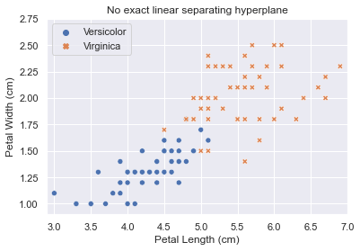

Furthermore, if we have a large number of features, this approach often leads to overfitting.

# Associated Exercises

# References